# Z = m + sd + E

Kasia Sawicka

July 2016

### Introduction

In case of kriging made maps, we cannot use geostatistical model:

[output not shown]

### Example case - calculating C/N ratio

The C/N ratio is a simple model that takes two imputs, carbon and nitrogen content in soil to calculate the output. It is important to know the spatial covarage of C/N as it is important indicator of soil quality and usability for crop growth. The C and N are measured at a point location and spatial covarage can be obtained with point interpolation using kriging.

We use Africa Soil Profile Database from the ‘GSIF’ package. You can install it from CRAN.

### Code with explanations here

Run some preliminaries.

```r
# Load packages
library(sp)
library(gstat)
library(GSIF)
library(magrittr)
library(StatDA)
library(rgdal)
library(raster)
```

The model through which the uncertainties will be propagating needs to be defined as an R function.

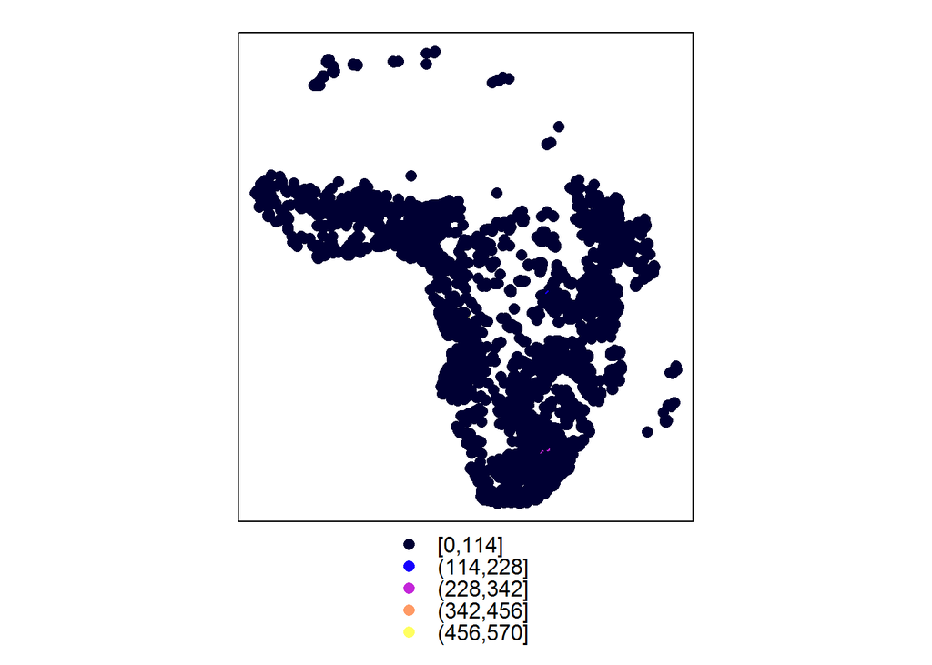

```r
# Define the model
CNratio <- function(carbon, nitrogen) {
  carbon/nitrogen
}

# Load the data
data(afsp)

# get coordinates from _sites to _horizons
afsp_sites <- afsp[[1]]
afsp_horizons <- afsp[[2]]
afsp_horizons <- merge(afsp_horizons, afsp_sites)

# coerce to spatial object
coordinates(afsp_horizons) <- ~LONWGS84+LATWGS84
spplot(afsp_horizons["ORCDRC"])
```

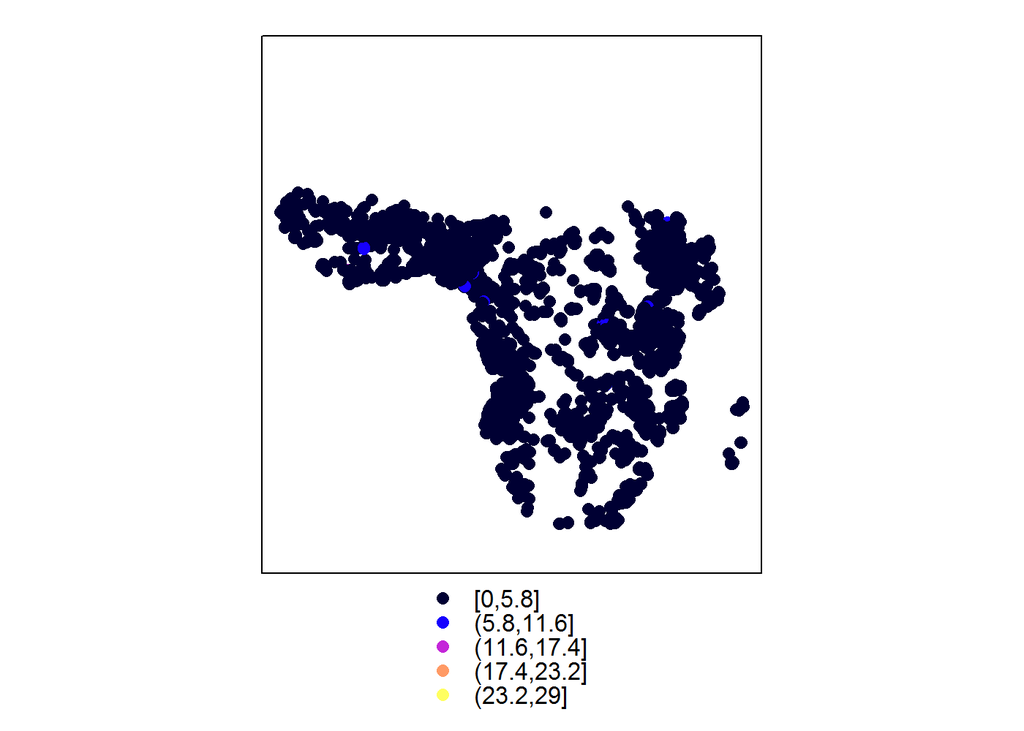

```r
spplot(afsp_horizons["NTO"])
```

```r
kenya <- readOGR(dsn = "d:\\GD\\Wageningen\\QUICS\\RPackage\\spup\\vignettes\\C_N",
                 layer = "Kenya_admin_2014_WGS84")
```

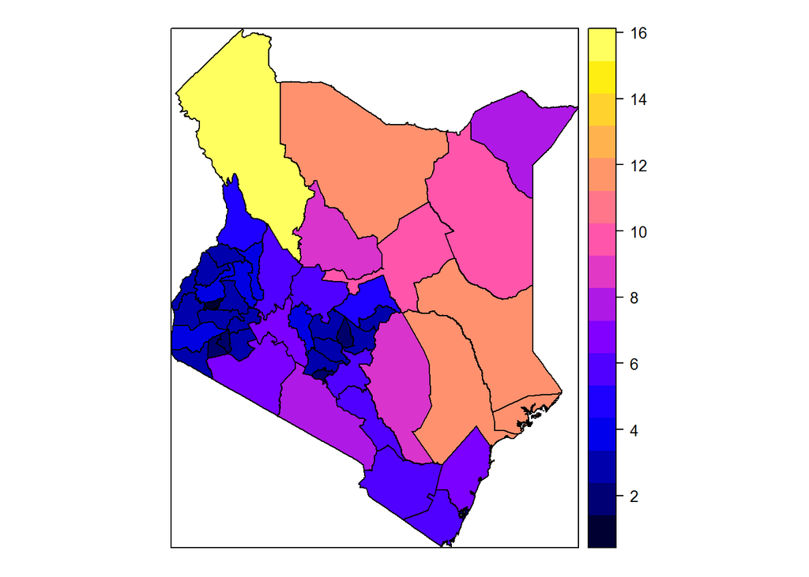

```r
spplot(kenya["Shape_Leng"])
```

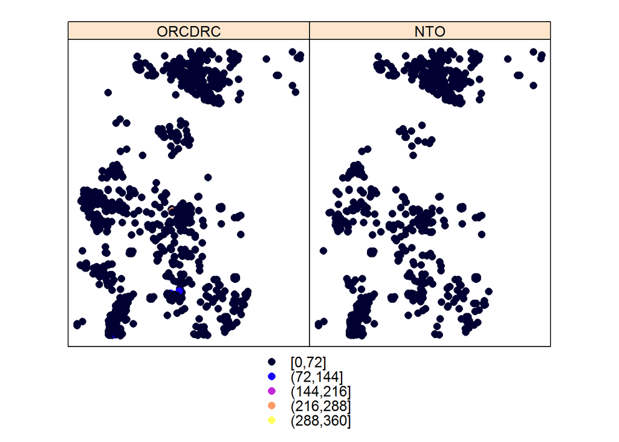

```r
kenya_afsp <- crop(afsp_horizons, extent(kenya))
spplot(kenya_afsp[c("ORCDRC", "NTO")])
```